Ullrich Köthe: **Fundamentals of Machine Learning**, Winter Semester 2018/19  
Notebook created by Jakob Kruse & Nicolas Roth & Jens Beyermann

# Solutions for Exercise 1

In order to run this notebook, you have to install the `pandas` package:  
`conda install pandas`

```python
import numpy as np

import matplotlib.pyplot as plt
%matplotlib notebook

import pandas as pd
pd.options.display.float_format = '{:,.2f}'.format

from IPython.display import display
from sklearn import model_selection
from sklearn.neighbors import KNeighborsClassifier
```

# 1 Monte-Carlo simulation

Wikipedia entry: [**Inverse transform sampling**](https://en.wikipedia.org/wiki/Inverse_transform_sampling)

Probability density functions (pdf): $$ p(\,X\,|\,Y= 0\,) = f_0(x) = \begin{cases} 2 - 2x, & x \in [0,1] \\ 0, & \text{otherwise} \end{cases} $$

$$ p(\,X\,|\,Y= 1\,) = f_1(x) = \begin{cases} 2x, & x \in [0,1] \\ 0, & \text{otherwise} \end{cases} $$

Cumulative distribution functions (cdf) for $x\in[0,1]$:

\begin{align} P(\, X < x\,|\, Y = 0\,) &= F_{X,0}(x) = \int _{-\infty}^{x} f_0(t) \,dt \\ &= \int _{0}^{x} (2 - 2t) \,dt = [\, 2t - t^2 \,]_{0}^x \\ &= 2x - x^2 = u \end{align}

\begin{align} P(\, X < x\,|\, Y = 1\,) &= F_{X,1}(x) = \int _{-\infty}^{x} f_1(t) \,dt \\ &= \int _{0}^{x} 2t \,dt = [\, t^2 \,]_{0}^x \\ &= x^2 = u \end{align}

Inverse cumulative distribution functions (solve the above for $u\in[0,1]$): $$ F_{X,0}^{-1}(u) = 1 - \sqrt{1-u} $$

$$ F_{X,1}^{-1}(u) = \sqrt{u} $$

## 1.1 Data Creation and Visualization

```python
def create_data(N):
    data = np.zeros((N, 2), dtype = np.float32)
    for i in range(N):
        # sample y uniformly between 0 and 1
        y = np.random.randint(2)
        # use inverse transform sampling for x, given y
        u = np.random.rand()
        if 0 == y:
            x = 1 - np.sqrt(1 - u)
        else:
            x = np.sqrt(u)
        data[i,:] = (x,y)
    return data
```

```python
# create a data set to visualize the distributions
test_data = create_data(100000)
X_0 = test_data[test_data[:,1] == 0][:,0]
X_1 = test_data[test_data[:,1] == 1][:,0]
```

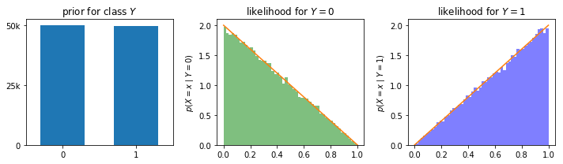

```python
# show prior and likelihoods for both classes as bar chart and histograms
fig = plt.figure(figsize = (10, 3))

plt.subplot(131)
plt.title(r'prior for class $Y$')
plt.bar([0, 1], [X_0.size, X_1.size], width = 0.6)
plt.xticks([0,1]); plt.xlim([-0.5, 1.5]); plt.yticks([0,25000,50000], ['0', '25k', '50k'])

plt.subplot(132)
plt.title(r'likelihood for $Y = 0$')
plt.hist(X_0, 50, density = True, facecolor = 'green', alpha = 0.5)
plt.ylabel(r'$p(X = x \mid Y = 0)$')
plt.plot([0,1], [2,0])

plt.subplot(133)
plt.title(r'likelihood for $Y = 1$')
plt.hist(X_1, 50, density = True, facecolor = 'blue', alpha = 0.5)
plt.ylabel(r'$p(X = x \mid Y = 1)$')
plt.plot([0,1], [0,2])

fig.tight_layout(); plt.show()
```

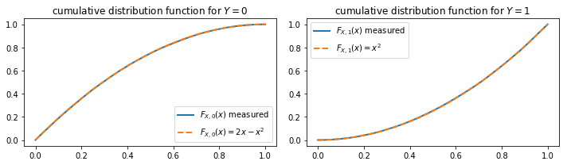

```python
# show cumulative distribution functions for both classes as plots
fig = plt.figure(figsize = (10, 3))
domain = np.linspace(0, 1, 50)

plt.subplot(121)
plt.title(r'cumulative distribution function for $Y = 0$')
cdf_0 = np.array([np.count_nonzero(X_0 < t) for t in domain], dtype = np.float64); cdf_0 /= cdf_0.max()
plt.plot(domain, cdf_0, label = r'$F_{X,0}(x)$ measured', linewidth = 2)
plt.plot(domain, 2*domain - np.square(domain), '--', label = r'$F_{X,0}(x) = 2x - x^2$', linewidth = 2)
plt.legend(loc = 'lower right')

plt.subplot(122)
plt.title(r'cumulative distribution function for $Y = 1$')
cdf_1 = np.array([np.count_nonzero(X_1 < t) for t in domain], dtype = np.float64); cdf_1 /= cdf_1.max()
plt.plot(domain, cdf_1, label = r'$F_{X,1}(x)$ measured', linewidth = 2)
plt.plot(domain, np.square(domain), '--', label = r'$F_{X,1}(x) = x^2$', linewidth = 2)
plt.legend(loc = 'upper left')

fig.tight_layout(); plt.show()
```

## 1.2 Classification by Thresholding

```python
# two simple threshold classifiers
def pred_A(x,t): return 0 if (x <= t) else 1
def pred_B(x,t): return 1 if (x <= t) else 0
def pred_C(): return np.random.randint(2)
def pred_D(): return 1

# true error rates
def error_A(t): return 100 * (0.25 + np.square(t - 0.5))
def error_B(t): return 100 * (0.75 - np.square(t - 0.5))
def error_C(): return 50
def error_D(): return 50

values_A = np.zeros((3,9))
values_B = np.zeros((3,9))
values_C = np.zeros((3,9))
values_D = np.zeros((3,9))
ts = [0.2, 0.5, 0.6]
Ms = [10, 100, 1000, 10000]

for t in range(3):
    values_A[t,0] = error_A(ts[t]); values_B[t,0] = error_B(ts[t])
    values_C[t,0] = error_C(); values_D[t,0] = error_D()


    for M in range(4):
        errors_A = []; errors_B = []
        errors_C = []; errors_D = []

        # run 10 experiments each with different test set sizes
        for i in range(10):
            data = create_data(Ms[M])
            n_errors_A = n_errors_B = 0
            n_errors_C = n_errors_D = 0
            for m in range(Ms[M]):
                if pred_A(data[m,0], ts[t]) != data[m,1]: n_errors_A += 1
                if pred_B(data[m,0], ts[t]) != data[m,1]: n_errors_B += 1
                if pred_C() != data[m,1]: n_errors_C += 1
                if pred_D() != data[m,1]: n_errors_D += 1
            errors_A.append(100 * float(n_errors_A) / Ms[M])
            errors_B.append(100 * float(n_errors_B) / Ms[M])
            errors_C.append(100 * float(n_errors_C) / Ms[M])
            errors_D.append(100 * float(n_errors_D) / Ms[M])

        values_A[t, 2*M+1:2*M+3] = np.mean(errors_A), np.std(errors_A)
        values_B[t, 2*M+1:2*M+3] = np.mean(errors_B), np.std(errors_B)
        values_C[t, 2*M+1:2*M+3] = np.mean(errors_C), np.std(errors_C)
        values_D[t, 2*M+1:2*M+3] = np.mean(errors_D), np.std(errors_D)
```

```python
# display as Pandas DataFrames
display(pd.DataFrame(
        data = values_A,
        index = ['t = 0.2', 't = 0.5', 't = 0.6'],
        columns = ['[true]', 10, 'std', 100, 'std', 1000, 'std', 10000, 'std'])
        .rename_axis('A', axis = 'columns'))
display(pd.DataFrame(
        data = values_B,
        index = ['t = 0.2', 't = 0.5', 't = 0.6'],
        columns = ['[true]', 10, 'std', 100, 'std', 1000, 'std', 10000, 'std'])
        .rename_axis('B', axis = 'columns'))
display(pd.DataFrame(
        data = values_C,
        index = ['run 1', 'run 2', 'run 3'],
        columns = ['[true]', 10, 'std', 100, 'std', 1000, 'std', 10000, 'std'])
        .rename_axis('C', axis = 'columns'))
display(pd.DataFrame(
        data = values_D,
        index = ['run 1', 'run 2', 'run 3'],
        columns = ['[true]', 10, 'std', 100, 'std', 1000, 'std', 10000, 'std'])
        .rename_axis('D', axis = 'columns'))
```

| A | [true] | 10 | std | 100 | std | 1000 | std | 10000 | std |
| --- | --- | --- | --- | --- | --- | --- | --- | --- | --- |
| t = 0.2 | 34.00 | 36.00 | 9.17 | 35.30 | 3.69 | 34.23 | 1.10 | 33.98 | 0.40 |
| t = 0.5 | 25.00 | 31.00 | 15.13 | 27.10 | 4.68 | 24.92 | 1.15 | 24.71 | 0.41 |
| t = 0.6 | 26.00 | 28.00 | 9.80 | 25.60 | 3.75 | 26.12 | 1.36 | 25.93 | 0.36 |

| B | [true] | 10 | std | 100 | std | 1000 | std | 10000 | std |
| --- | --- | --- | --- | --- | --- | --- | --- | --- | --- |
| t = 0.2 | 66.00 | 64.00 | 9.17 | 64.70 | 3.69 | 65.77 | 1.10 | 66.02 | 0.40 |
| t = 0.5 | 75.00 | 69.00 | 15.13 | 72.90 | 4.68 | 75.08 | 1.15 | 75.29 | 0.41 |
| t = 0.6 | 74.00 | 72.00 | 9.80 | 74.40 | 3.75 | 73.88 | 1.36 | 74.07 | 0.36 |

| C | [true] | 10 | std | 100 | std | 1000 | std | 10000 | std |
| --- | --- | --- | --- | --- | --- | --- | --- | --- | --- |
| run 1 | 50.00 | 52.00 | 14.70 | 50.40 | 4.82 | 50.20 | 0.94 | 50.12 | 0.48 |
| run 2 | 50.00 | 53.00 | 11.87 | 50.90 | 4.44 | 49.79 | 1.43 | 50.19 | 0.60 |
| run 3 | 50.00 | 50.00 | 20.00 | 50.20 | 5.53 | 50.77 | 2.38 | 49.63 | 0.68 |

| D | [true] | 10 | std | 100 | std | 1000 | std | 10000 | std |
| --- | --- | --- | --- | --- | --- | --- | --- | --- | --- |
| run 1 | 50.00 | 47.00 | 6.40 | 50.00 | 3.38 | 49.68 | 1.27 | 50.22 | 0.35 |
| run 2 | 50.00 | 45.00 | 14.32 | 51.90 | 5.72 | 49.50 | 2.15 | 50.00 | 0.68 |
| run 3 | 50.00 | 44.00 | 13.56 | 49.50 | 5.85 | 50.47 | 1.25 | 49.86 | 0.37 |

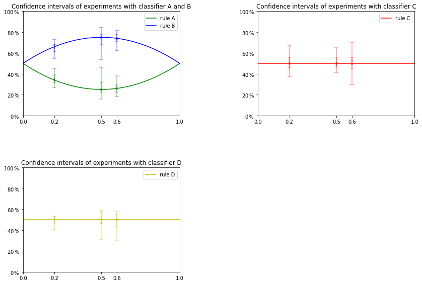

```python
# plot error rate as a function of t, plus experimental results
domain = np.linspace(0, 1, 50)
plt.subplot(2, 2, 1)
plt.plot(domain, error_A(domain), 'g', label = r'rule A')
plt.plot(domain, error_B(domain), 'b', label = r'rule B')
for i in range(4):
    plt.errorbar(ts, values_A[:,2*i+1], yerr = values_A[:,2*i+2],
                 fmt = 'none', color = 'g', linewidth = 2, alpha = .3, capsize = 4-i, capthick = 2)
    plt.errorbar(ts, values_B[:,2*i+1], yerr = values_B[:,2*i+2],
                 fmt = 'none', color = 'b', linewidth = 2, alpha = .3, capsize = 4-i, capthick = 2)
plt.yticks([0,20,40,60,80,100], [r'$0\,\%$', r'$20\,\%$', r'$40\,\%$', r'$60\,\%$', r'$80\,\%$', r'$100\,\%$'])
plt.xticks([0,0.2,0.5,0.6,1]); plt.xlim(0,1)
plt.title('Confidence intervals of experiments with classifier A and B')
plt.legend();

plt.subplot(2, 2, 2)
plt.plot(domain, [error_C()]*len(domain), 'r', label = r'rule C')
for i in range(4):
    plt.errorbar(ts, values_C[:,2*i+1], yerr = values_C[:,2*i+2],
                 fmt = 'none', color = 'r', linewidth = 2, alpha = .3, capsize = 4-i, capthick = 2)
plt.yticks([0,20,40,60,80,100], [r'$0\,\%$', r'$20\,\%$', r'$40\,\%$', r'$60\,\%$', r'$80\,\%$', r'$100\,\%$'])
plt.xticks([0,0.2,0.5,0.6,1]); plt.xlim(0,1)
plt.title('Confidence intervals of experiments with classifier C')
plt.legend();

plt.subplot(2, 2, 3)
plt.plot(domain, [error_D()]*len(domain), 'y', label = r'rule D')
for i in range(4):
    plt.errorbar(ts, values_D[:,2*i+1], yerr = values_D[:,2*i+2],
                 fmt = 'none', color = 'y', linewidth = 2, alpha = .3, capsize = 4-i, capthick = 2)
plt.yticks([0,20,40,60,80,100], [r'$0\,\%$', r'$20\,\%$', r'$40\,\%$', r'$60\,\%$', r'$80\,\%$', r'$100\,\%$'])
plt.xticks([0,0.2,0.5,0.6,1]); plt.xlim(0,1)
plt.title('Confidence intervals of experiments with classifier D')
plt.legend();

plt.subplots_adjust(top=1.8, bottom=0, left=0, right=1.8, hspace=0.5,
                    wspace=0.5)
plt.show()
```

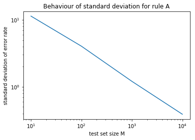

```python
# plot change in standard deviation with increasing M
plt.plot([10, 100, 1000, 10000], np.mean(values_A[:, [2,4,6,8]], axis = 0))
plt.title('Behaviour of standard deviation for rule A') # for rule B it's identical
plt.ylabel('standard deviation of error rate'); plt.xlabel('test set size M')
plt.loglog(); plt.show()
```

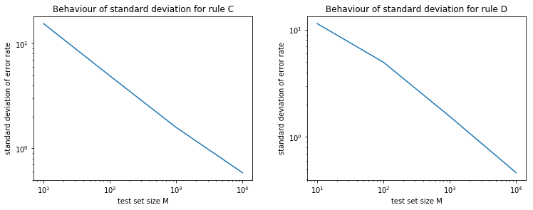

```python
fig = plt.figure()
plt.subplot(1, 2, 1)
plt.plot([10, 100, 1000, 10000], np.mean(values_C[:, [2,4,6,8]], axis = 0))
plt.title('Behaviour of standard deviation for rule C')
plt.ylabel('standard deviation of error rate'); plt.xlabel('test set size M')
plt.loglog()

plt.subplot(1, 2, 2)
plt.plot([10, 100, 1000, 10000], np.mean(values_D[:, [2,4,6,8]], axis = 0))
plt.title('Behaviour of standard deviation for rule D')
plt.ylabel('standard deviation of error rate'); plt.xlabel('test set size M')
plt.loglog()
plt.subplots_adjust(top=0.8, bottom=0, left=0, right=1.6, hspace=0.25,
                    wspace=0.25)
plt.show()
```